# Final project

Yuchi Liu

2025-04-03

# Introduction

Heart disease is one of the leading causes of death worldwide. Early prediction and identification of risk factors associated with heart disease are crucial for effective prevention and intervention strategies. By analyzing characteristics and clinical measurements, we can better understand the relationships between various health indicators and heart disease risk. The dataset used in this study is sourced from Kaggle. It contains 918 observations and 12 variables, including demographic information (e.g., age, sex), clinical measurements (e.g.,cholesterol), and whether the individual has been diagnosed with heart disease.The dataset consists of a mix of numerical and categorical variables.

## Analysis objectives

The primary objective of this analysis is to explore the associations between heart disease and other characteristics. We aim to investigate potential risk factors by comparing demographic and clinical measurements between individuals with and without heart disease,perform statistical tests to determine whether specific variables (e.g., age, cholesterol) are significantly associated with heart disease, and visualize relationships between heart disease and key predictors to enhance interpretability.

```r
data <- read.csv(here::here("data", "heart.csv"), header = TRUE)
head(data)
```

```
##   Age Sex ChestPainType RestingBP Cholesterol FastingBS RestingECG MaxHR
## 1  40   M           ATA       140         289         0     Normal   172
## 2  49   F           NAP       160         180         0     Normal   156
## 3  37   M           ATA       130         283         0         ST    98
## 4  48   F           ASY       138         214         0     Normal   108
## 5  54   M           NAP       150         195         0     Normal   122
## 6  39   M           NAP       120         339         0     Normal   170
##   ExerciseAngina Oldpeak ST_Slope HeartDisease
## 1              N     0.0       Up            0
## 2              N     1.0     Flat            1
## 3              N     0.0       Up            0
## 4              Y     1.5     Flat            1
## 5              N     0.0       Up            0
## 6              N     0.0       Up            0
```

# Table analysis

Below we report some tables to summary statistics of this dataset and find key predictors using statistics and p-values.

Summary Statistics of Heart Failure Dataset

|  | Age | Sex | ChestPainType | RestingBP | Cholesterol | FastingBS | RestingECG | MaxHR | ExerciseAngina | Oldpeak | ST_Slope | HeartDisease |
| --- | --- | --- | --- | --- | --- | --- | --- | --- | --- | --- | --- | --- |
|  | Min. :28.00 | Length:918 | Length:918 | Min. : 0.0 | Min. : 0.0 | Min. :0.0000 | Length:918 | Min. : 60.0 | Length:918 | Min. :-2.6000 | Length:918 | Min. :0.0000 |
|  | 1st Qu.:47.00 | Class :character | Class :character | 1st Qu.:120.0 | 1st Qu.:173.2 | 1st Qu.:0.0000 | Class :character | 1st Qu.:120.0 | Class :character | 1st Qu.: 0.0000 | Class :character | 1st Qu.:0.0000 |
|  | Median :54.00 | Mode :character | Mode :character | Median :130.0 | Median :223.0 | Median :0.0000 | Mode :character | Median :138.0 | Mode :character | Median : 0.6000 | Mode :character | Median :1.0000 |
|  | Mean :53.51 | NA | NA | Mean :132.4 | Mean :198.8 | Mean :0.2331 | NA | Mean :136.8 | NA | Mean : 0.8874 | NA | Mean :0.5534 |
|  | 3rd Qu.:60.00 | NA | NA | 3rd Qu.:140.0 | 3rd Qu.:267.0 | 3rd Qu.:0.0000 | NA | 3rd Qu.:156.0 | NA | 3rd Qu.: 1.5000 | NA | 3rd Qu.:1.0000 |
|  | Max. :77.00 | NA | NA | Max. :200.0 | Max. :603.0 | Max. :1.0000 | NA | Max. :202.0 | NA | Max. : 6.2000 | NA | Max. :1.0000 |

The table above breaks down the data types and presents summary statistics for the key variables in the dataset, including age, resting blood pressure, serum cholesterol, and maximum heart rate. These statistics help us get an initial idea of the overall distribution of the data.

| **Characteristic** | **Overall** N = 918<sup>1</sup> | **Heart Disease Analysis** **0** N = 410<sup>1</sup> | **Heart Disease Analysis** **1** N = 508<sup>1</sup> | **p-value**<sup>2</sup> |  |
| --- | --- | --- | --- | --- | --- |
| age | 54 (47, 60) | 51 (43, 57) | 57 (51, 62) |  | <0.001 |
| Sex |  |  |  | <0.001 |  |
| F | 193 (21%) | 143 (35%) | 50 (9.8%) |  |  |
| M | 725 (79%) | 267 (65%) | 458 (90%) |  |  |
| resting blood pressure | 130 (120, 140) | 130 (120, 140) | 132 (120, 145) | <0.001 |  |
| serum cholesterol | 223 (173, 267) | 227 (197, 267) | 217 (0, 267) | <0.001 |  |
| maximum heart rate achieved | 138 (120, 156) | 150 (134, 165) | 126 (112, 145) | <0.001 |  |

<sup>1</sup> Median (Q1, Q3); n (%)  
<sup>2</sup> Wilcoxon rank sum test; Pearson’s Chi-squared test

# Graphical analysis

Below we report some plots to see relationships between heart disease and key predictors.

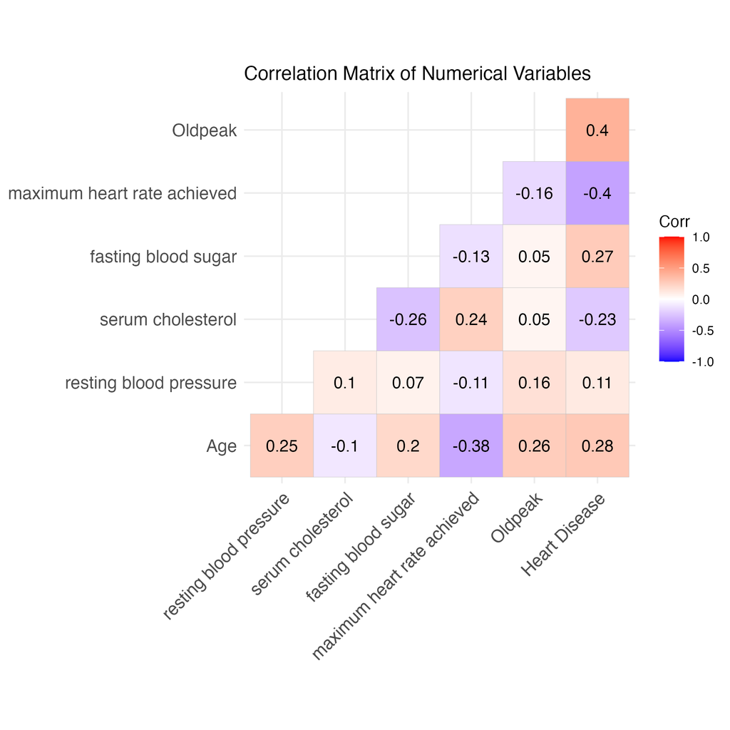

The figure above presents the correlation matrix of numerical variables in the dataset. The heatmap visualizes Pearson correlation coefficients, where: Red indicates a strong positive correlation (closer to +1), Blue indicates a strong negative correlation (closer to -1), White indicates little to no correlation (close to 0). The numeric values in each square represent the correlation coefficient between two variables. Age and MaxHR exhibit a moderate negative correlation (r = -0.38), indicating that older individuals tend to have lower maximum heart rates. HeartDisease is positively correlated with Age (r = 0.28) and negatively correlated with MaxHR (r = -0.40), suggesting that older individuals and those with lower MaxHR are more likely to have heart disease.

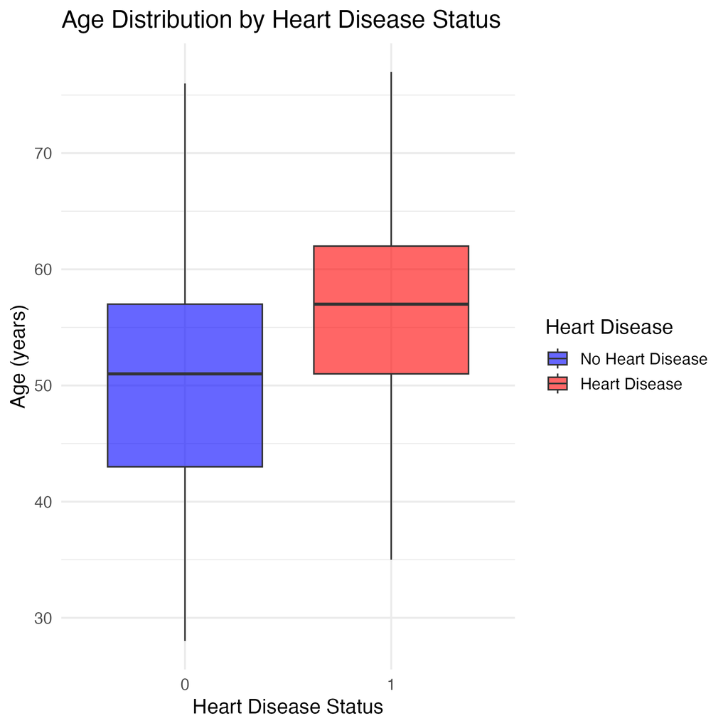

The results suggest that individuals with heart disease tend to be older on average compared to those without heart disease. This trend is reflected in the median age, which is higher in the heart disease group. The p-value from our statistical test further confirms a significant association between age and heart disease.